# Correction DM1-2-3

# Solution de la premiere moitie du controle continu

## Chargement des librairies necessaires au controle continu

```r
library(tidyverse)
library(ggpubr)
```

# Definission du repertoire de travail

```r
setwd("~/Desktop/2021_L3_R/session2_ggplot/materiel")
```

## Import des donnees avec la fonction read_tsv car le fichier contient des colonnes separees par tabulation

```r
nitrate_data <- read_tsv("data/Cheng_2021_Arabidopsis_N.txt")
```

## Definition du nombre de lignes et colonnes

```r
dim(nitrate_data)
```

```
## [1] 532   5
```

Il y a 532 lignes et 5 colonnes

## Boxplot du poids des plantes (DryWeight_g, axe y), en fonction de l’Accession (axe x), avec l’interieur des boxplot colores en fonction de du type de traitement d’azote (Nlevel).

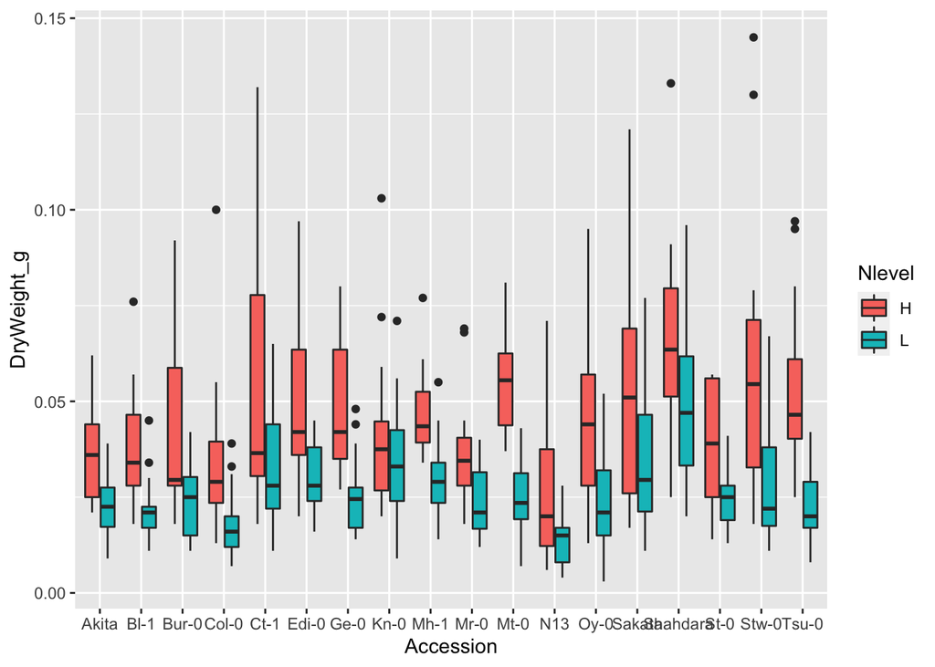

```r
ggplot(nitrate_data, aes(x= Accession, y=DryWeight_g, fill=Nlevel)) +
  geom_boxplot()
```

## Ajout du resultat d’un test de comparaison de moyennes entre les deux niveaux d’azote pour chacune des accessions.

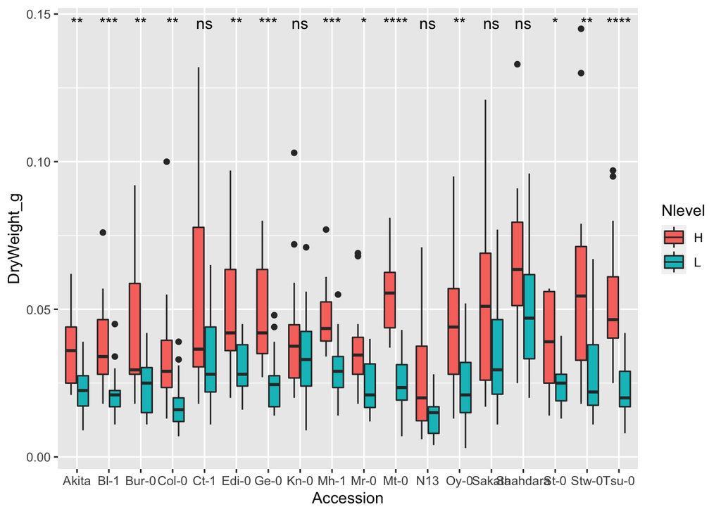

```r
ggplot(nitrate_data, aes(x= Accession, y=DryWeight_g, fill=Nlevel)) +
  geom_boxplot() +
  stat_compare_means(method="wilcox.test", label="p.signif")
```

## Interpretation du graphique:

Nous observons une augmentation significative du poids des plantes d’Arabidopsis quand elles poussent avec une concentration forte en azote par rapport a une concentration faible en azote pour la plupart des accessions testees. Seules les accessions Ct-1, kn-0, N13, Sakata et Shahdara ne presentent pas d’effet du poids des plantes en reponse a un changement de la concentration d’azote.

## Selection de toutes les colonnes de l’objet nitrate_data sauf la colonne Nlevel.

```r
select(nitrate_data, -Nlevel)
```

```
## # A tibble: 532 × 4
##    Accession Rep   DryWeight_g AppliedN_mg
##    <chr>     <chr>       <dbl>       <dbl>
##  1 Akita     one         0.044        15.5
##  2 Akita     one         0.039        15.5
##  3 Akita     one         0.037        15.5
##  4 Akita     one         0.036        15.5
##  5 Akita     one         0.035        15.5
##  6 Akita     one         0.024        15.5
##  7 Akita     two         0.062        19.9
##  8 Akita     two         0.061        19.9
##  9 Akita     two         0.059        19.9
## 10 Akita     two         0.044        19.9
## # … with 522 more rows
```

# Selection des lignes de l’objet nitrate_data qui sont l’accession Col-0.

```r
filter(nitrate_data, Accession=="Col-0")
```

```
## # A tibble: 29 × 5
##    Accession Nlevel Rep   DryWeight_g AppliedN_mg
##    <chr>     <chr>  <chr>       <dbl>       <dbl>
##  1 Col-0     H      one         0.03         15.5
##  2 Col-0     H      one         0.028        15.5
##  3 Col-0     H      one         0.022        15.5
##  4 Col-0     H      one         0.019        15.5
##  5 Col-0     H      two         0.1          19.9
##  6 Col-0     H      two         0.055        19.9
##  7 Col-0     H      two         0.049        19.9
##  8 Col-0     H      two         0.04         19.9
##  9 Col-0     H      two         0.036        19.9
## 10 Col-0     H      two         0.028        19.9
## # … with 19 more rows
```